# 信頼区間推定とモデルの依存度に関するまとめ

UPDATE: 2022-10-28 20:37:22

# はじめに

黒木先生の下記のノートが勉強になったので、ノートを参考に自分でも試してみた。 モデルや仮定を今以上に意識しないといけない・・・自戒。

- 母平均の仮説検定と区間推定

下記では、標準正規分布から乱数を発生させて信頼区間を確認、二峰性分布から乱数を発生させて 正規分布モデルに基いた区間推定が破綻するかを確認している。

サンプルサイズは100で、シミュレーション回数は1000としている。二峰性分布の設定は、母集団のうち95%は標準正規分布に、残りの5%は平均50、分散1の正規分布に従っているとした。

```r
library(tidyverse)
# Set parameter
N   <- 100
M1  <- 0
S1  <- 1
M2  <- 50
S2 <- 1
P1 <- 0.95
P2 <- 0.05
M <- M1*P1 + M2*P2
sim_n <- 1:1000
```

## 標準正規分布を使ったシミュレーション

一般的に言われる、100回信頼区間を計算したら95回は$\mu$を含むというよう説明に合う結果が得られている。

```r
# Simulation 1: y ~ nromal(mu = 0, sd = 1)
res_mean <- res_ci_lwr <- res_ci_upr <- vector(mode = 'numeric', length = length(sim_n))
for (i in seq_along(sim_n)) {
  set.seed(i)
  data <- rnorm(n = N, mean = M1, sd = S1)
  res_test <- t.test(data, conf.level = 0.95)
  res_mean[[i]]   <- res_test$estimate[[1]]
  res_ci_lwr[[i]] <- res_test$conf.int[[1]]
  res_ci_upr[[i]] <- res_test$conf.int[[2]]
}

# Make data frame
df <- tibble::tibble(id = sim_n,
           mean = res_mean,
           ci_lwr = res_ci_lwr,
           ci_upr = res_ci_upr) %>%
  dplyr::mutate(is_in = if_else(M1 >= ci_lwr & M1 <= ci_upr, 'in', 'out'))

# Count intervals which is in teh range
df %>%
  dplyr::count(is_in) %>%
  dplyr::mutate(ratio = n / sum(n))
```

```
## # A tibble: 2 × 3
##   is_in     n ratio
##   <chr> <int> <dbl>
## 1 in      959 0.959
## 2 out      41 0.041
```

シミュレーションを可視化しておく。

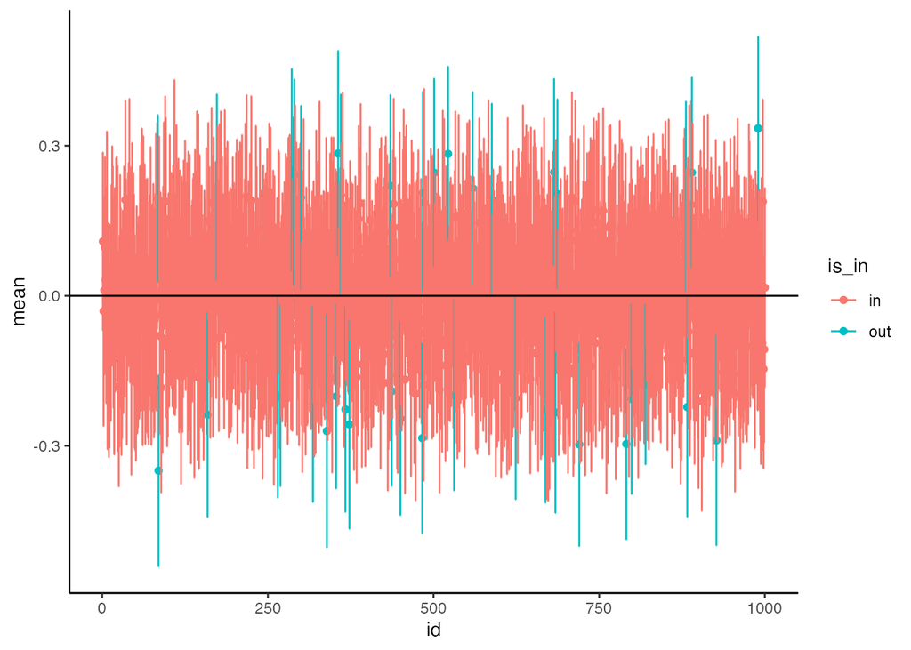

```r
# Plot simulation
ggplot(df, aes(id, mean, col = is_in)) +
  geom_point() +
  geom_errorbar(aes(ymin = ci_lwr, ymax = ci_upr)) +
  geom_hline(yintercept = M1) +
  theme_classic()
```

## 二峰性分布を使ったシミュレーション

二峰性分布を可視化しておく。

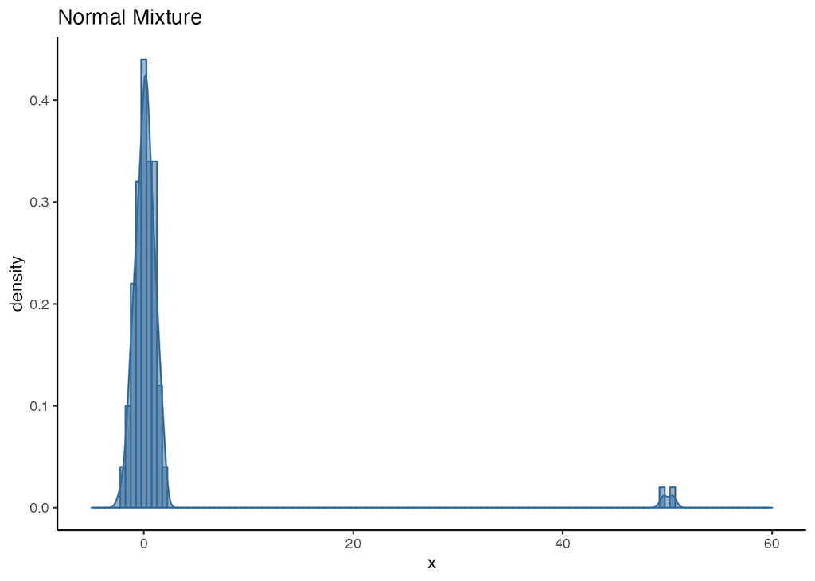

```r
# Bimodal distribution
x1 <- rnorm(n = 100, mean = M1, sd = S1)
x2 <- rnorm(n = 100, mean = M2, sd = S2)
w  <- rbinom(n = 100, size = 1, prob = P1)
x  <- w * x1 + (1 - w) * x2

ggplot(data = tibble(x = x), aes(x, y = ..density.., col = 1, fill = 1)) +
  geom_histogram(position = 'identity', binwidth = 0.5, alpha = 1/2) +
  geom_density(alpha = 1/2) +
  theme_classic() +
  theme(legend.position = 'none') +
  xlim(c(-5, 60)) +
  ggtitle('Normal Mixture')
```

```r
# Simulation 2: y ~ Bimodal distribution
res_mean <- res_ci_lwr <- res_ci_upr <- vector(mode = 'numeric', length = length(sim_n))
for (i in seq_along(sim_n)) {
  set.seed(i)
  x1 <- rnorm(n = N, mean = M1, sd = S1)
  x2 <- rnorm(n = N, mean = M2, sd = S2)
  w  <- rbinom(n = N, size = 1, prob = P1)
  data  <- w * x1 + (1-w) * x2
  res_test <- t.test(data, conf.level = 0.95)
  res_mean[[i]]   <- res_test$estimate[[1]]
  res_ci_lwr[[i]] <- res_test$conf.int[[1]]
  res_ci_upr[[i]] <- res_test$conf.int[[2]]
}

# Make dataframe
df_bimodal <- tibble::tibble(id = sim_n,
                     mean = res_mean,
                     ci_lwr = res_ci_lwr,
                     ci_upr = res_ci_upr) %>%
  dplyr::mutate(is_in = if_else(M >= ci_lwr & M <= ci_upr, 'in', 'out'))

# Count intervals which is in teh range
df_bimodal %>%
  dplyr::count(is_in) %>%
  dplyr::mutate(ratio = n / sum(n))
```

```
## # A tibble: 2 × 3
##   is_in     n ratio
##   <chr> <int> <dbl>
## 1 in      885 0.885
## 2 out     115 0.115
```

なるほど、面白い。たしかに、データがどのような母集団から生成されているのを無視して、正規分布を仮定するモデルを使用するのは危険である。

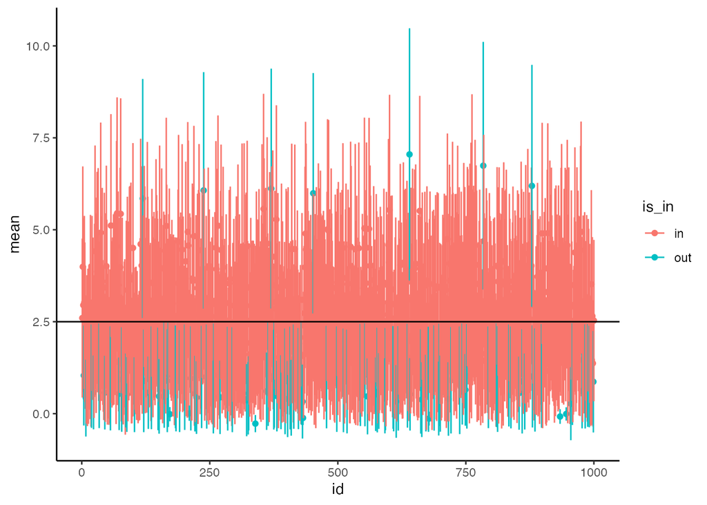

```r
# Plot simulation
ggplot(df_bimodal, aes(id, mean, col = is_in)) +
  geom_point() +
  geom_errorbar(aes(ymin = ci_lwr, ymax = ci_upr), width = .1) +
  geom_hline(yintercept = M) +
  theme_classic()
```